# Statistical Account of Scotland Analysis. HCA Deep Dive

Lucia Michelin

14/02/2024

# Introduction

So let’s see some thinking more interesting!

# Our Dataset

The Statistical Accounts of Scotland are a series of documentary publications, related in subject matter though published at different times, covering life in Scotland in the 18th and 19th.

The Old (or First) Statistical Account of Scotland was published between 1791 and 1799 by Sir John Sinclair of Ulbster. The New (or Second) Statistical Account of Scotland published under the auspices of the General Assembly of the Church of Scotland between 1834 and 1845. These first two Statistical Accounts of Scotland are unique records of life during the agricultural and industrial revolutions in Europe.

## Structure of the dataset

The original publication has been scanned and OCRed and each single record has been collected in a .txt file. The name of each file contain information about the document itself. For example StAS.2.15.91.P.Orkney.Cross_and_Burness

- StAs.2.15.91 -> Second Statistical Account
- P -> Parish (Contain information from the Parish)
- Orkney -> Area of interest (Scotland has been divided in 33 Areas)
- Cross_and_Burness -> Parish

We are going to see how to use this to extract information about all our text later but the first thing we need to do is to create a single dataframe (table) that will contain all the texts otherwise it will be very difficult to manage the data.

## Prepare the dataset

All our .txt files are in a directory named Account so I can write a function that will loop through each of the files extract the text and the tile of each file and put them all in a table. Doing it manually would take a ridiculous amount of time but that is what computer are for so let’s see what we can do.

1. Create a new object that contain the path to our directory

```r
text_files_dir <- "Accounts"
```

2. Create an empty data.table that we are going to populate with the info we are going to extract

```r
text_files <- list.files(text_files_dir, pattern = "\\.txt$", full.names = TRUE)#search for .txt

Scotdata <- data.table(title = character(), text = character())# create a table with two column one named title and one text
```

3. Iterate through each text file We do this by using a forloop function

```r
for (file in text_files) {
  # Specify the encoding (e.g., "latin1")
  text <- tolower(iconv(readLines(file, warn = FALSE), from = "latin1", to = "UTF-8", sub = ""))# tolower gets all text low cap
  title <- gsub(".txt$", "", basename(file))# gsub extracts the pattern define so the tile of the files before .txt
  Scotdata <- rbindlist(list(Scotdata, data.table(title = title, text = paste(text, collapse = " "))))# bind them together
}
```

4. look at the first 5 row of our file and save the table as a .csv so I do not have to do it every single time

```r
head(Scotdata)
```

```
##                                         title
## 1:  StAS.1.1.1.C.NullCounty.Contents_and_Misc
## 2:             StAS.1.1.1.P.Roxburgh.Jedburgh
## 3: StAS.1.1.10.C.NullCounty.Contents_and_Misc
## 4:            StAS.1.1.10.P.Roxburgh.Jedburgh
## 5:         StAS.1.1.100.P.Linlithgow.Carriden
## 6:            StAS.1.1.101.P.Ayrshire.Coylton
##                                                                                                                                                                                                                                                                                                          …
## 1:                                                                                                                                                                                                                                                                                                       …
## 2:                                                                                                                                                                                                                                                                                                       …
## 3:                                                                                                                                                                                                                                                                                                       …
## 4:       statistical account  sown in the ground immediately surrounding the town of  jedburgh, and some on tiviot fide; but little or none in the south part of the parish.  turnips and potatoes are a gene- ral crop all over this country.  the culture of turnips, in particular, has been much stud…
## 5:                                                                                                                                                                                                                                                                                                       …
## 6:                                                                                                                                                                                                                                                                                                       …
```

```r
write.csv(Scotdata, "text_data.csv", row.names = FALSE)
```

## Clean and format the data

### Fix some formatting issues

Fix the going to the next line issue. i.e. sub “-” with nothing “” There are a lot of formatting errors (next line, next paragraph) that we want to clean up

```r
ScotdataClean <- mutate_if(Scotdata,
                           is.character, #apply the changes only if the data is a "character" type (e.g. text)
                           str_replace_all,
                           pattern = "-[[:space:]]+","") #What I am searching for+ what I am subbing with
```

### Extract More info from the dataset

To do the following steps we are using regex. Short for regular expression, a regex is a string of text that lets you create patterns that help match, locate, and manage text. Think find and replace in Word

1. Extract area and parish from the title
- P=Parish
- C=Miscellanea
- G=General Observations
- A=Appendix
- F=General
- I=Index
- M=Map

I want to be able to subset the dataset by those and I also want to have them both as a code as a description to do so I need to write a if else clause

```r
ScotdataClean$Type<- sub(".*(P|C|G|A|F|M|I)\\.(.*?)\\..*", "\\1", ScotdataClean$title)#This is selecting the P|C|G|A|F|M|I
ScotdataClean$TypeDescriptive<- ifelse(
  ScotdataClean$Type =="P", "Parish",ifelse(
    ScotdataClean$Type =="C","Miscellanea", ifelse(
      ScotdataClean$Type =="G","General Observations", ifelse(
        ScotdataClean$Type =="A", "Appendix", ifelse(
          ScotdataClean$Type =="F","General", ifelse(
            ScotdataClean$Type =="I", "Index","Map"))))))
```

2. I want the first bit of the title as the RecordId of the document

```r
ScotdataClean$RecordID<- sub("^(StAS\\.\\d+\\.\\d+\\.\\d+).*","\\1",  ScotdataClean$title)
```

3. I also want to extract the area that is the bit after p/c/g/a/f/m/i

```r
ScotdataClean$Area<- sub(".*(P|C|G|A|F|M|I)\\.(.*?)\\..*", "\\2", ScotdataClean$title)# //2 cause I want to select the second bit so after the letters
```

4. Extract the Parish. I can do so by extracting the last bit up until the full stop

```r
ScotdataClean$Parish<- sub(".*\\.", "", ScotdataClean$title)
```

5. Extract dates from the text I know all dates are cluster of 4 numbers starting with 1 (there are no recent dates)

```r
ScotdataClean$Year<-sapply(str_extract_all(ScotdataClean$text, "\\b1[1-9]{3}\\b"), function(matches) {
  if (length(matches) > 0) {
    paste(matches, collapse = ", ")
  } else {
    NA
  }
})
```

```r
ScotdataClean$Tables <- str_match(ScotdataClean$text, "<table>(.*?)</table>")[, 2]
```

### Subset the dataset to only keep the text with information from the parishes

We will now start to look at what is inside but before starting our analysis we want to work only on the parish observations since a lot of the other documents are part of indexes or summaries

```r
Parish<-subset(ScotdataClean, Type =="P")
```

# Explore the dataset created

Create a Quanteda corpus of the ‘text’ column from our data set A corpus class object containing the original texts, document-level variables, document-level metadata, corpus-level metadata, and default settings for subsequent processing of the corpus. For quanteda >= 2.0, this is a specially classed character vector.

```r
CorpusStat<-corpus(Parish$text)
```

## Summarise the content of the corpus

Print doc in position 5 of the corpus

```r
summary(CorpusStat, 5)
```

```
## Corpus consisting of 27065 documents, showing 5 documents:
##
##   Text Types Tokens Sentences
##  text1    94    171         1
##  text2   167    399         1
##  text3   122    201         1
##  text4   123    262         1
##  text5   146    273         1
```

Check how many docs are in the corpus

```r
ndoc(CorpusStat)
```

```
## [1] 27065
```

Check number of characters in the first 10 documents of the corpus

```r
nchar(CorpusStat[1:10])
```

```
##  text1  text2  text3  text4  text5  text6  text7  text8  text9 text10
##    948   1914   1018   1253   1362   1430   2003   1924   1866   1983
```

Check number of tokens in the first 10 documents

```r
ntoken(CorpusStat[1:10])
```

```
##  text1  text2  text3  text4  text5  text6  text7  text8  text9 text10
##    171    399    201    262    273    281    422    387    365    454
```

## Visualise this information

1. Create a new vector with tokens for all articles and store the vector as a new data frame with four columns (Tokens, title, Area, Parish)

```r
NtokenStats<-as.vector(ntoken(CorpusStat))
TokenScotland <-data.frame(Tokens=NtokenStats, title=Parish$title, Area=Parish$Area, Parish=Parish$Parish)
```

2. Now we want to see how much material we have for each area. We can do that through a Pipe.

R pipes are a way to chain multiple operations together in a concise and expressive way. They are represented by the %>% operator, which takes the output of the expression on its left and passes it as the first argument to the function on its right. Using pipes in R allows us to link a sequence of analysis steps.

```r
BreakoutScotland<- TokenScotland %>%
  group_by(Area)%>%
  summarize(NReports=n(), # count n report
            MeanTokens=round(mean(Tokens)))# mean of n of token per area
```

3. Plot the results

Now we can plot the trends. This is done through the use of the ggplot package that is a very handy package that will allow you to print a very big variety of graphs

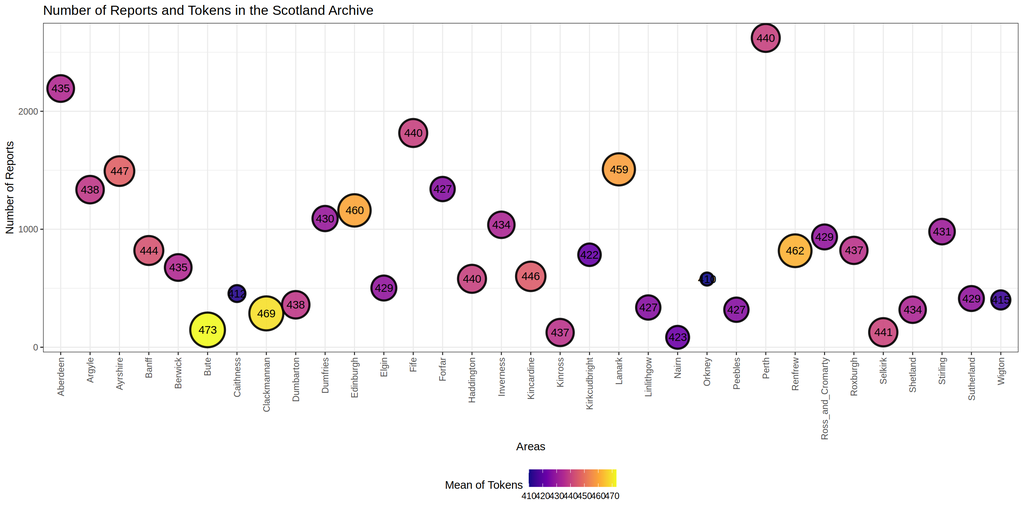

```r
ggplot(BreakoutScotland, aes(x=Area, y=NReports))+ # Select data set and coordinates we are going to plot
  geom_point(aes(size=MeanTokens, fill=MeanTokens),shape=21, stroke=1.5, alpha=0.9, colour="black")+ # Which graph I want
  labs(x = "Areas", y = "Number of Reports", fill = "Mean of Tokens", size="Mean of Tokens", title="Number of Reports and Tokens in the Scotland Archive")+ # Rename labs and title
  scale_size_continuous(range = c(5, 15))+ # Resize the dots to be bigger
  geom_text(aes(label=MeanTokens))+ # Add the mean of tokens in the dots
  scale_fill_viridis_c(option = "plasma")+ # Change the colour coding
  theme_bw()+ # B/W Background
  theme(axis.text.x = element_text(angle = 90, vjust = 0.5, hjust = 1), legend.position = "bottom")+ # Rotate labels of x and move them slightly down. Plus move the position to the bottom
  guides(size = "none") # Remove the Size from the Legend
```

# Getting the data ready for text analysis

1. Tokenise Now, we can tokenise the corpus, which will break the textual data into separate words grouped by document. We are also removing symbols, URLs, and punctuation.

```r
Report_tokens <- quanteda::tokens(Parish$text,
                                  remove_symbols=TRUE,
                                  remove_url=TRUE,
                                  remove_punct=TRUE,
                                  remove_numbers = FALSE,
                                  split_hyphens = TRUE)
```

2. Check details Take a look at our tokens list by printing the second document:

```r
Report_tokens[2]
```

```
## Tokens consisting of 1 document.
## text2 :
##  [1] "statistical" "account"     "sown"        "in"          "the"
##  [6] "ground"      "immediately" "surrounding" "the"         "town"
## [11] "of"          "jedburgh"
## [ ... and 333 more ]
```

3. Remove short words Remove tokens under 3 characters. (Shorter words won’t tell us much about our data, and because we removed punctuation, we want to get rid of the truncated contractions–e.g. I’m –>‘I’, ‘m’)

```r
Report_tokens <- tokens_select(Report_tokens, min_nchar = 3)
```

4. Remove stop words

Stop words are a set of commonly used words in a language. Examples of stop words in English are “a,” “the,” “is,” “are,” etc. Stop words are commonly used in Text Mining and Natural Language Processing (NLP) to eliminate words that are so widely used that they carry very little useful information Report_tokens <-tokens_remove(Report_tokens, c(stopwords(“english”), “statistical”, “account”, “parish”, “one”, “years”))

```r
Report_tokens <-tokens_remove(Report_tokens, c(stopwords("english"), "statistical", "account", "parish", "one", "years"))
```

# Working with Geographical Data

Since our data are all connected with places in Scotland we can look at topics within our dataset and how popular they are in different areas of Scotland.

To do so we need to work with a geoPackage containing the same information about the areas of Scotland contained in the dataset. GeoPackage is an open, portable, self-describing, compact format for transferring geo-spatial information. In our case it is a vectorial representation of the areas of Scotland in which the accounts are subdivided.

## Ilness mentions

For our first example we are going to look at mentions of ilness-related terminology across Scotland.

1. Check for keywords and add them to the data dataset

```r
Parish$Ilness<- ifelse(grepl("ill|ilness|sick|cholera", Parish$text, ignore.case = T), "yes","no")
```

2. Group by the Ilness column and geographical area

Because, as we have seen earlier the number of records collected for each area is very different we are going to use a proportion rather than just the number of occurrences of ilness-related words.

```r
IlnessGroup <- Parish %>%
  group_by(Area) %>%
  summarise(Total = n(), count = sum(Ilness == "yes")) %>%
  mutate(per = round(count/Total, 2))# calculate every how many
```

3. Read Geographical Data (geopackage)

```r
ParishesGeo <- readOGR(dsn = here("Spatial/Parishes.gpkg"))
```

4. Merge the two dataset

```r
MergedGeo <-merge(ParishesGeo,IlnessGroup, by.x="JOIN_NAME_", by.y="Area",all.x = TRUE)# nb this is left join cause I want to preserve all the records present in ParishGeo
```

5. Create a continuous color palette

```r
color.palette <- colorRampPalette(c("white", "red"))
```

6. Plot using spplot

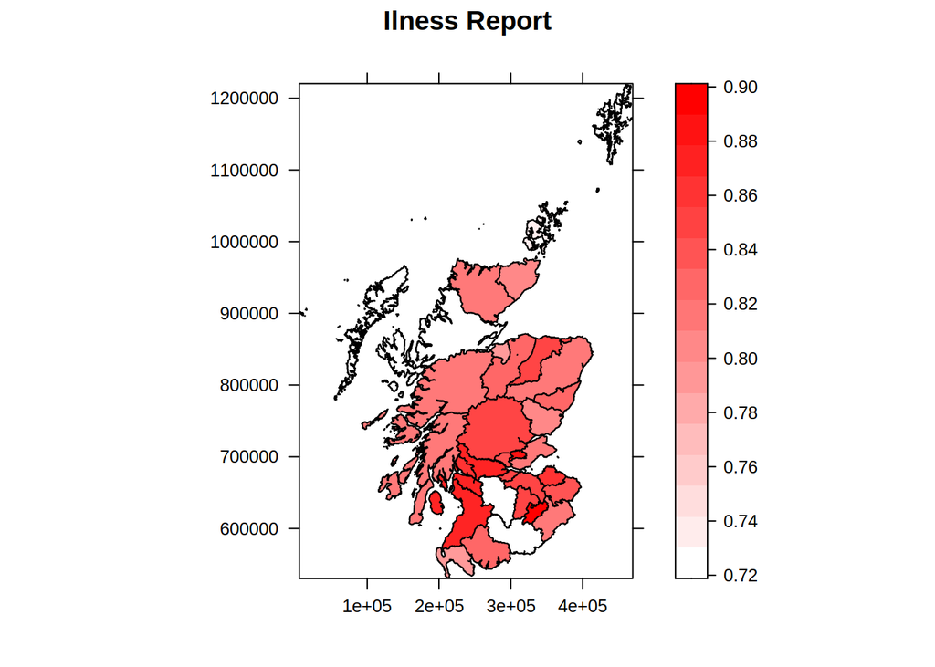

```r
spplot(MergedGeo,
       "per",
       col.regions = color.palette(100),
       main = "Ilness Report",
       key.space = "right",
       sp.layout = list("sp.polygons", MergedGeo, col = "black", pch = 19),
       scales = list(draw = TRUE))
```

## Witches Mentions

Where can we find more mentions of witches related facts.

1. Check for keywords and add them to the data dataset

```r
Parish$witches<- ifelse(grepl("witch|spell|witches|enchantemt|magic", Parish$text, ignore.case = T), "yes","no")
```

2. Group by the witches column and geographical area

```r
WitchGroup <- Parish %>%
  group_by(Area) %>%
  summarise(Total = n(), count = sum(witches == "yes")) %>%
  mutate(per = round(count / Total, 2))
```

3. Merge the two dataset

```r
MergedGeo2 <-merge(ParishesGeo,WitchGroup, by.x="JOIN_NAME_", by.y="Area",all.x = TRUE)# nb this is left join cause I want to preserve all the records present in ParishGeo
```

4. Create a continuous color palette

```r
color.palette2 <- colorRampPalette(c("white", "purple"))
```

5. Plot using spplot

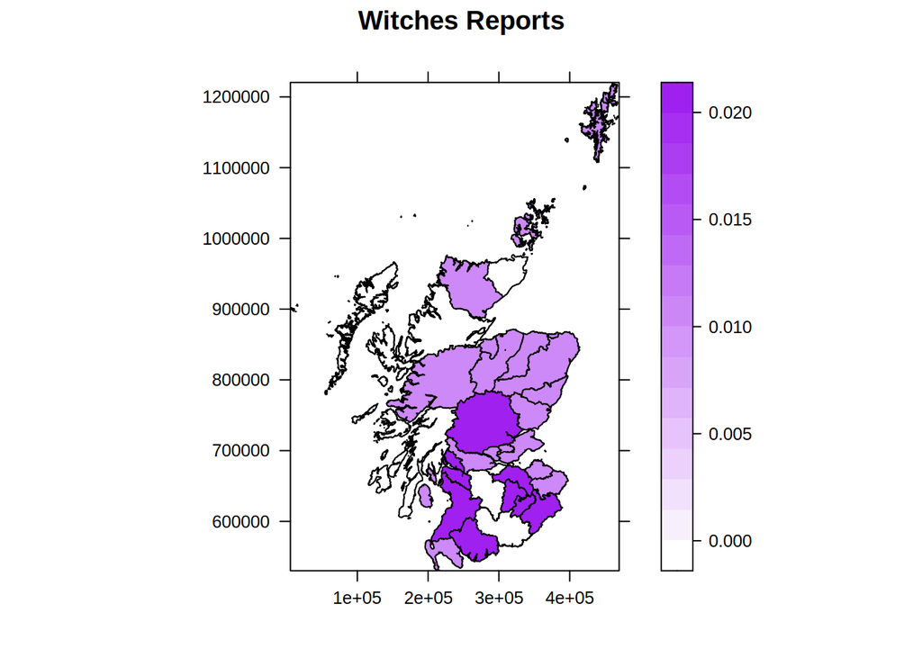

```r
spplot(MergedGeo2,
       "per",
       col.regions = color.palette2(100),
       main = "Witches Reports",
       key.space = "right",
       sp.layout = list("sp.polygons", MergedGeo, col = "black", pch = 19),
       scales = list(draw = TRUE))
```